# Analysis of environmental movements affectiveness

INFO 526 - Summer 2024 - Final Project

This project will look into the effectiveness of the recent increase in environmental movements and how they have changed the pollutants being removed from rivers and streams

Author

Affiliation

Cole Johnson

School of Information, University of Arizona

## Introduction

One of the big worries of my generation has been global warming and other environmental issues, causing many news articles to be made regarding environmental issues. With this increasing news surrounding big environmental movements I thought it would be interesting to see if any of these movements are effective in reducing or changing the type of pollutants that are being found in rivers.

The data set that I will use to investigate this information is the trashwheel data set from tidyverse, which presents information regarding the amount of pollutants removed from rivers by trashwheels, Trash removal devices located at the end of rivers. This data set includes quantities of specific items that are being removed from rivers, such as plastic bottles. I will mutate this data to create quantities of recyclables and non-recyclables. I supplemented this with data regarding when the most prominent environmental movements took place over the last decade. By analyzing visualizations made from these two data sets we will clearly see the effectiveness that environmental movements have on river pollutants.

## Question 1: How are environmental movements affecting the Trash Wheel’s pollutant collections at the end of rivers?

### Introduction

For this question I want to know the effects that environmental movements have on the pollutants that are being thrown into rivers where trash wheels are located. I would like to know if the amount of pollutants are decreasing and if the type of pollutants (recyclable versus non recyclable) are changing as a result of big environmental movements. I am interested in looking at this data because I have heard a ton of news over the last few years about environmental movements being more and more important and effective. I would like to know if all of these events actually change anything in peoples mind about pollutants or recyclables.

### Approach

For the first visualization, I will be using a geom smooth line plot to tell if there is a trend of overall pollutants or non-recyclable pollutants. A decreasing trend of either overall pollutants or non-recyclable pollutants would mean that the environmental movements are successful at benefiting the environment. On this plot I will have vertical lines labeled by environmental movement dates, from this we can see if any one of the environmental movements had a large impact on types or quantities of pollutants being removed from rivers.

For the second visualization, I will be using a stacked bar chart grouped by most recent environmental movement on the x-axis and ordered by environmental movement date. This bar chart will only be looking at recyclable versus non-recyclable pollutants and will show if there is a clear trend of pollutants becoming more recyclable as well as which movements have more of an impact on that trend.

### Analysis

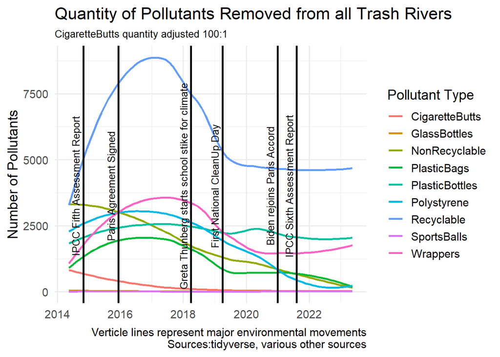

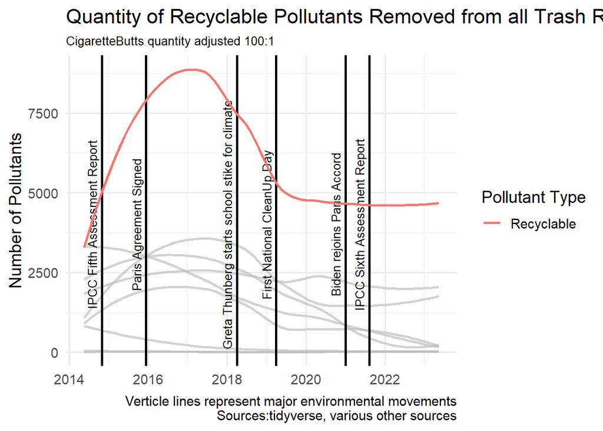

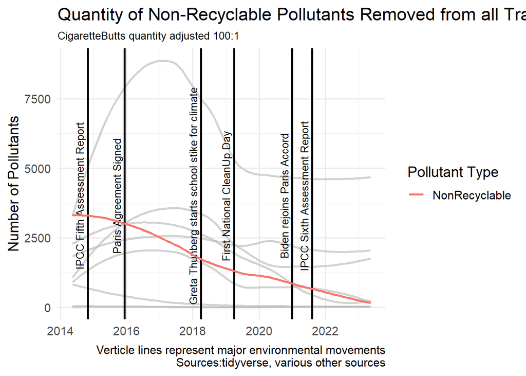

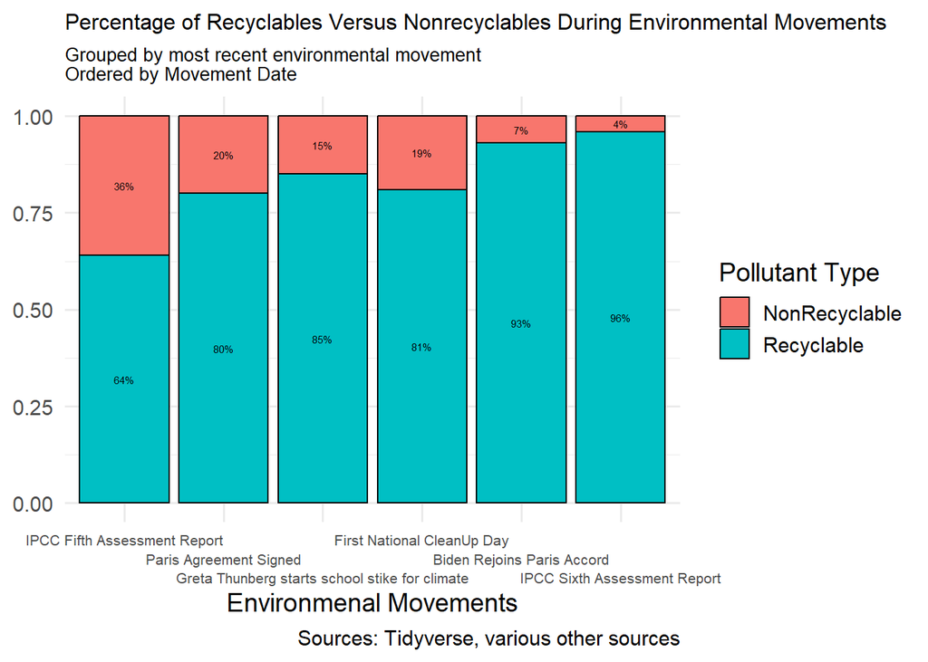

This visualization shows percentage of recyclable and non-recyclable pollutants in rivers following each environmental movement’s occurrence. The visualization shows a direct comparison between recyclables and non-recyclable pollutants with percentage values of each which makes each environmental movements effect on types of pollutants very apparent. Although we see the same trend that was present in the prior visualization, the amount of non recyclables being greatly reduced over time, we also see something that wasn’t very apparent in the last visualization. This visualization shows us that following the First National Cleanup Day, the percentage of non-recyclable pollutants actually increased in comparison to recyclable pollutants.

### Discussion

The second visualization backs up all the insights gained from the first visualization. However, this visualization clearly shows that the first national clean up day had a negative impact on the ratio of non-recyclables to recyclables. When pairing this information with the first plot, we can see that the amount of recyclable pollutants decreased much further as a response to the first national clean up day, when compared to the amount of non-recyclable pollutants.